# I. Geometric Distribution

The geometric distribution models the waiting time until the first success in a sequence of independent Bernoulli trials. In this activity, the probability of success on each trial is $p = 0.2$.

R’s `rgeom()` function generates the number of failures before the first success. Since the problem asks for the number of trials required to achieve the first success, 1 is added to every generated value.

## 1. Set the probability of success

```r
p <- 0.2
p
```

```
## [1] 0.2
```

The probability of success in every trial is 0.2.

## 2. Generate 1,000 geometric random variables

A seed is set so that the same simulated sample and numerical results are obtained whenever the document is rendered.

```r
set.seed(1110)

n <- 1000

# rgeom() returns failures before the first success.
# Add 1 to obtain total trials required for the first success.
x <- rgeom(n = n, prob = p) + 1

# Display the first 20 simulated values.
head(x, 20)
```

```
##  [1]  4 11  1  1  4  2  9 14 14  3 15  4  9 16  3  7  6  3  7  5
```

A total of 1000 observations were generated.

## 3. Calculate the basic statistics

```r
mean_x <- mean(x)
var_x  <- var(x)
sd_x   <- sd(x)

mean_x
```

```
## [1] 5.095
```

```r
var_x
```

```
## [1] 24.40038
```

```r
sd_x
```

```
## [1] 4.939674
```

For comparison, the theoretical statistics for the number of trials until the first success are:

$$E(X) = \frac{1}{p}$$

$$\operatorname{Var}(X) = \frac{1-p}{p^2}$$

$$\operatorname{SD}(X) = \sqrt{\frac{1-p}{p^2}}$$

```r
theoretical_mean <- 1 / p
theoretical_variance <- (1 - p) / p^2
theoretical_sd <- sqrt(theoretical_variance)

theoretical_mean
```

```
## [1] 5
```

```r
theoretical_variance
```

```
## [1] 20
```

```r
theoretical_sd
```

```
## [1] 4.472136
```

## 4. Print the required formatted output

```r
cat(
  "Number of trials required to achieve first success:",
  length(x),
  "\n"
)
```

```
## Number of trials required to achieve first success: 1000
```

```r
cat(
  sprintf("Mean (in 2 decimal places): %.2f\n", mean_x)
)
```

```
## Mean (in 2 decimal places): 5.09
```

```r
cat(
  sprintf("Variance (in 2 decimal places): %.2f\n", var_x)
)
```

```
## Variance (in 2 decimal places): 24.40
```

```r
cat(
  sprintf("Standard deviation (in 2 decimal places): %.2f\n", sd_x)
)
```

```
## Standard deviation (in 2 decimal places): 4.94
```

The simulated statistics should be reasonably close to the theoretical mean of 5.00, variance of 20.00, and standard deviation of 4.47. Small differences are expected because the values were obtained from a random simulation.

## 5. Plot the histogram

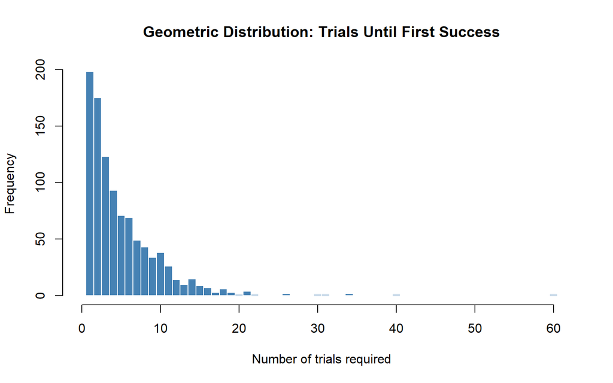

Histogram of simulated trials required to achieve the first success.

```r
hist(
  x,
  breaks = seq(0.5, max(x) + 0.5, by = 1),
  main = "Geometric Distribution: Trials Until First Success",
  xlab = "Number of trials required",
  ylab = "Frequency",
  col = "steelblue",
  border = "white",
  xlim = c(0, max(x) + 1)
)
```

The histogram is right-skewed. Lower trial counts occur more frequently because there is a chance of success on every trial. Large waiting times are possible, but they become progressively less frequent.

# II. Hypergeometric Distribution

Suppose 10% of the IC chips in each box are defective. A sample of 10 chips is selected without replacement.

Let $X$ denote the number of defective chips in the sample. The phrase “more than 10% defective” means:

$$\frac{X}{10} > 0.10$$

Therefore:

$$X > 1$$

Since $X$ is an integer, the event is equivalent to $X \ge 2$. Thus, the required probability is:

$$P(X > 1) = 1 - P(X \le 1)$$

In R, the hypergeometric cumulative distribution function is:

```
phyper(q, m, n, k)
```

where:

- `q` is the largest number of defectives included in the cumulative probability;
- `m` is the number of defective chips in the box;
- `n` is the number of non-defective chips in the box; and
- `k` is the sample size.

## 1. Sample of 10 from a box of 40

A box of 40 contains:

- $0.10(40) = 4$ defective chips;
- $40 - 4 = 36$ non-defective chips; and
- a sample size of 10 chips.

```r
box_size_40 <- 40
defective_40 <- 0.10 * box_size_40
nondefective_40 <- box_size_40 - defective_40
sample_size <- 10

# P(X > 1) = 1 - P(X <= 1)
prob_more_10_40 <- phyper(
  q = 1,
  m = defective_40,
  n = nondefective_40,
  k = sample_size,
  lower.tail = FALSE
)

cat(
  sprintf(
    "Probability for a sample of 10 from a box of 40: %.6f\n",
    prob_more_10_40
  )
)
```

```
## Probability for a sample of 10 from a box of 40: 0.255881
```

```r
cat(
  sprintf(
    "Percentage probability: %.2f%%\n",
    100 * prob_more_10_40
  )
)
```

```
## Percentage probability: 25.59%
```

As a manual check, the same result can be computed by adding the probabilities for 2, 3, and 4 defective chips:

```r
x_values_40 <- 2:min(defective_40, sample_size)

probability_check_40 <- sum(
  dhyper(
    x_values_40,
    m = defective_40,
    n = nondefective_40,
    k = sample_size
  )
)

probability_check_40
```

```
## [1] 0.2558814
```

**Interpretation:** The probability that more than 10% of the 10 sampled chips are defective is approximately 0.2559, or 25.59%.

## 2. Sample of 10 from a box of 5,000

A box of 5,000 contains:

- $0.10(5000) = 500$ defective chips;
- $5000 - 500 = 4500$ non-defective chips; and
- a sample size of 10 chips.

```r
box_size_5000 <- 5000
defective_5000 <- 0.10 * box_size_5000
nondefective_5000 <- box_size_5000 - defective_5000

# P(X > 1) = 1 - P(X <= 1)
prob_more_10_5000 <- phyper(
  q = 1,
  m = defective_5000,
  n = nondefective_5000,
  k = sample_size,
  lower.tail = FALSE
)

cat(
  sprintf(
    "Probability for a sample of 10 from a box of 5000: %.6f\n",
    prob_more_10_5000
  )
)
```

```
## Probability for a sample of 10 from a box of 5000: 0.263862
```

```r
cat(
  sprintf(
    "Percentage probability: %.2f%%\n",
    100 * prob_more_10_5000
  )
)
```

```
## Percentage probability: 26.39%
```

**Interpretation:** The probability that more than 10% of the 10 sampled chips are defective is approximately 0.2639, or 26.39%.

## Comparison of the two cases

```r
comparison <- data.frame(
  Box_Size = c(40, 5000),
  Defective_Chips = c(defective_40, defective_5000),
  Nondefective_Chips = c(nondefective_40, nondefective_5000),
  Sample_Size = c(sample_size, sample_size),
  Probability = c(prob_more_10_40, prob_more_10_5000),
  Percentage = c(
    100 * prob_more_10_40,
    100 * prob_more_10_5000
  )
)

knitr::kable(
  comparison,
  digits = c(0, 0, 0, 0, 6, 2),
  col.names = c(
    "Box size",
    "Defective",
    "Non-defective",
    "Sample size",
    "Probability",
    "Percentage"
  ),
  caption = "Probability that more than 10% of the sampled chips are defective"
)
```

Probability that more than 10% of the sampled chips are defective

| Box size | Defective | Non-defective | Sample size | Probability | Percentage |
| --- | --- | --- | --- | --- | --- |
| 40 | 4 | 36 | 10 | 0.255881 | 25.59 |
| 5000 | 500 | 4500 | 10 | 0.263862 | 26.39 |

The probability for the larger box is close to the corresponding binomial probability because sampling 10 chips has very little effect on a population of 5,000. In the box of 40, sampling without replacement produces a stronger finite-population effect.

# Conclusion

The geometric simulation models the total number of trials needed to obtain the first success when the success probability is 0.2. The simulated statistics are close to the theoretical geometric-distribution values.

For the hypergeometric problems, “more than 10% defective” in a sample of 10 means at least 2 defective chips. The required probabilities were calculated using the upper tail of the hypergeometric distribution.